# Lab 6

STA 206 | Fall 2021

## Nonadditive model with Interactions

In the previous lab, we saw different aspects of multiple linear regression with only first order terms. Now suppose we want to fit a model that includes all two-way interactions of the predictors. We will use the `patient.txt` data from the previous lab.

You can add interaction terms by using “:” in the `lm` formula. For example, if we want to include the interaction between A and B, we write A:B.

**Note:** A*B = A+B+A:B

```r
patient = read.table("patient.txt")
names(patient) = c("satisfaction","age","severity","anxiety")

colnames(patient)[1] = "Y"
fit2 = lm(Y ~ age+severity+anxiety+age:severity+
age:anxiety+severity:anxiety, data=patient)
summary(fit2)
```

```
##
## Call:
## lm(formula = Y ~ age + severity + anxiety + age:severity + age:anxiety +
##     severity:anxiety, data = patient)
##
## Residuals:
##     Min      1Q  Median      3Q     Max
## -17.842  -7.151   1.279   8.052  15.063
##
## Coefficients:
##                   Estimate Std. Error t value Pr(>|t|)
## (Intercept)      190.51810  117.37011   1.623    0.113
## age                0.79293    3.15488   0.251    0.803
## severity          -3.14572    3.26554  -0.963    0.341
## anxiety          -14.40686   70.96754  -0.203    0.840
## age:severity       0.01565    0.06396   0.245    0.808
## age:anxiety       -1.19694    0.93509  -1.280    0.208
## severity:anxiety   0.93330    1.54466   0.604    0.549
##
## Residual standard error: 10.21 on 39 degrees of freedom
## Multiple R-squared:  0.6957, Adjusted R-squared:  0.6489
## F-statistic: 14.86 on 6 and 39 DF,  p-value: 9.358e-09
```

We can compare this summary with the summary of the first-order model, and we see that the $R^2$ and adjusted $R^2$ are relatively unchanged: $R^2$ is slightly increased while $R^2_a$ is slightly decreased. Thus, bringing in the interaction terms does not do much to account for variability in the response variable. It does not seem to be necessary to use this more complex model for this data.

We can use the ANOVA table to get SSE, SSR, and SSTO as before:

```r
anova(fit2)
```

```
## Analysis of Variance Table
##
## Response: Y
##                  Df Sum Sq Mean Sq F value    Pr(>F)
## age               1 8275.4  8275.4 79.3282 6.108e-11 ***
## severity          1  480.9   480.9  4.6101   0.03806 *
## anxiety           1  364.2   364.2  3.4908   0.06923 .
## age:severity      1    8.9     8.9  0.0855   0.77148
## age:anxiety       1  133.4   133.4  1.2790   0.26500
## severity:anxiety  1   38.1    38.1  0.3651   0.54920
## Residuals        39 4068.4   104.3
## ---
## Signif. codes:  0 '***' 0.001 '**' 0.01 '*' 0.05 '.' 0.1 ' ' 1
```

We notice that the SSE is relatively close to what it was before, and thus so is SSR. SSTO should remain the same regardless of the model, since

$$SSTO = \sum_{i=1}^n (Y_i - \bar{Y})^2$$
does not depend on the model.

Suppose we wanted a confidence interval for the mean response at a given set of values of the X variables. For instance, let’s say we want a confidence interval for the mean satisfaction when age is 19, severity is 50, and anxiety is 2.1:

```r
newX = data.frame(age=19, severity=50, anxiety=2.1)
predict(fit2, newX, interval="confidence", level=0.99, se.fit=TRUE)
```

```
## $fit
##        fit      lwr      upr
## 1 83.15039 69.71023 96.59054
##
## $se.fit
## [1] 4.963288
##
## $df
## [1] 39
##
## $residual.scale
## [1] 10.21363
```

The se.fit option is telling R that we also want the standard errors. As before, we can switch the interval type to “prediction” if we want a prediction interval instead.

```r
predict(fit2, newX, interval="prediction", level=0.99, se.fit=TRUE)
```

```
## $fit
##        fit      lwr      upr
## 1 83.15039 52.40006 113.9007
##
## $se.fit
## [1] 4.963288
##
## $df
## [1] 39
##
## $residual.scale
## [1] 10.21363
```

Finally, if you wanted to fit a model with, say, just one interaction term, you could write:

```r
fit3 = lm(Y~age+severity+anxiety+anxiety:severity, data=patient)

##OR Equivalently

fit3 = lm(Y~age+severity*anxiety, data=patient)

summary(fit3)
```

```
##
## Call:
## lm(formula = Y ~ age + severity * anxiety, data = patient)
##
## Residuals:
##      Min       1Q   Median       3Q      Max
## -18.4007  -5.8432   0.4612   8.5402  17.0120
##
## Coefficients:
##                   Estimate Std. Error t value Pr(>|t|)
## (Intercept)      140.14938  110.40721   1.269    0.211
## age               -1.14052    0.21742  -5.246 5.07e-06 ***
## severity          -0.07586    2.22961  -0.034    0.973
## anxiety           -5.55837   47.50887  -0.117    0.907
## severity:anxiety  -0.15716    0.93287  -0.168    0.867
## ---
## Signif. codes:  0 '***' 0.001 '**' 0.01 '*' 0.05 '.' 0.1 ' ' 1
##
## Residual standard error: 10.18 on 41 degrees of freedom
## Multiple R-squared:  0.6824, Adjusted R-squared:  0.6514
## F-statistic: 22.02 on 4 and 41 DF,  p-value: 9.203e-10
```

If you wanted a model with a polynomial term, say age2, you could write:

```r
fit4 = lm(Y~age+severity+anxiety+I(age^2), data=patient)
summary(fit4)
```

```
##
## Call:
## lm(formula = Y ~ age + severity + anxiety + I(age^2), data = patient)
##
## Residuals:
##      Min       1Q   Median       3Q      Max
## -19.1934  -6.8513   0.3702   7.9900  16.9839
##
## Coefficients:
##               Estimate Std. Error t value Pr(>|t|)
## (Intercept) 169.654327  34.158440   4.967 1.25e-05 ***
## age          -1.719324   1.507972  -1.140    0.261
## severity     -0.460301   0.499264  -0.922    0.362
## anxiety     -13.276950   7.189966  -1.847    0.072 .
## I(age^2)      0.007409   0.019139   0.387    0.701
## ---
## Signif. codes:  0 '***' 0.001 '**' 0.01 '*' 0.05 '.' 0.1 ' ' 1
##
## Residual standard error: 10.16 on 41 degrees of freedom
## Multiple R-squared:  0.6834, Adjusted R-squared:  0.6525
## F-statistic: 22.12 on 4 and 41 DF,  p-value: 8.673e-10
```

If you had a model with three predictors and wanted all interactions (two-way and three-way) to be included, you could write (notice the last term):

```r
load("data1.Rdata")
fit5 = lm(Y~X1+X2+X3+X1:X2+X1:X3+X2:X3+X1:X2:X3, data=data1)

##OR Equivalently

fit5 = lm(Y~X1*X2*X3, data=data1)
summary(fit5)
```

```
##
## Call:
## lm(formula = Y ~ X1 * X2 * X3, data = data1)
##
## Residuals:
##      Min       1Q   Median       3Q      Max
## -2.27902 -0.59892  0.05091  0.64729  1.66547
##
## Coefficients:
##             Estimate Std. Error t value Pr(>|t|)
## (Intercept)  1.80303    0.26357   6.841 2.46e-08 ***
## X1           0.64906    0.22671   2.863  0.00652 **
## X2           3.47371    0.31529  11.018 5.75e-14 ***
## X3          -1.30334    0.49633  -2.626  0.01200 *
## X1:X2        1.42735    0.28833   4.950 1.25e-05 ***
## X1:X3        0.28232    0.46109   0.612  0.54364
## X2:X3       -0.06155    0.61661  -0.100  0.92096
## X1:X2:X3     3.07169    0.59172   5.191 5.71e-06 ***
## ---
## Signif. codes:  0 '***' 0.001 '**' 0.01 '*' 0.05 '.' 0.1 ' ' 1
##
## Residual standard error: 1.003 on 42 degrees of freedom
## Multiple R-squared:  0.9471, Adjusted R-squared:  0.9383
## F-statistic: 107.5 on 7 and 42 DF,  p-value: < 2.2e-16
```

We can also look into the anova for the above fit.

```r
anova(fit5)
```

```
## Analysis of Variance Table
##
## Response: Y
##           Df  Sum Sq Mean Sq  F value    Pr(>F)
## X1         1 148.285 148.285 147.3543 2.540e-15 ***
## X2         1 313.774 313.774 311.8056 < 2.2e-16 ***
## X3         1  11.194  11.194  11.1235  0.001790 **
## X1:X2      1 246.957 246.957 245.4072 < 2.2e-16 ***
## X1:X3      1   8.287   8.287   8.2351  0.006407 **
## X2:X3      1   1.734   1.734   1.7232  0.196409
## X1:X2:X3   1  27.117  27.117  26.9473 5.713e-06 ***
## Residuals 42  42.265   1.006
## ---
## Signif. codes:  0 '***' 0.001 '**' 0.01 '*' 0.05 '.' 0.1 ' ' 1
```

**Exercise** Consolidate the above findings using residual analysis. Fit a model with all 1st, 2nd and 3rd order terms except $X1*X3$ and $X2*X3$. And plot the residuals against these interactions to see if there is any pattern.

## Body Fat Example: partial coefficients; add-variable plots

- **Load the data into the R workspace**

```r
bodyfat=read.table("bodyfat_example.txt")
names(bodyfat)=c("X1","X2","X3","Y")
str(bodyfat)
```

```
## 'data.frame':    20 obs. of  4 variables:
##  $ X1: num  19.5 24.7 30.7 29.8 19.1 25.6 31.4 27.9 22.1 25.5 ...
##  $ X2: num  43.1 49.8 51.9 54.3 42.2 53.9 58.5 52.1 49.9 53.5 ...
##  $ X3: num  29.1 28.2 37 31.1 30.9 23.7 27.6 30.6 23.2 24.8 ...
##  $ Y : num  11.9 22.8 18.7 20.1 12.9 21.7 27.1 25.4 21.3 19.3 ...
```

```r
attach(bodyfat)
```

- **LS fitted regression coefficients as partial coefficients**

```r
##let's look at the LS fitted coefficient of X3 in Model 4
fit=lm(Y~X1+X2+X3)
fit$coefficients
```

```
## (Intercept)          X1          X2          X3
##  117.084695    4.334092   -2.856848   -2.186060
```

```r
anova(fit)
```

```
## Analysis of Variance Table
##
## Response: Y
##           Df Sum Sq Mean Sq F value    Pr(>F)
## X1         1 352.27  352.27 57.2768 1.131e-06 ***
## X2         1  33.17   33.17  5.3931   0.03373 *
## X3         1  11.55   11.55  1.8773   0.18956
## Residuals 16  98.40    6.15
## ---
## Signif. codes:  0 '***' 0.001 '**' 0.01 '*' 0.05 '.' 0.1 ' ' 1
```

```r
eY.12=lm(Y~X1+X2)$residuals
e3.12=lm(X3~X1+X2)$residuals
fit3=lm(eY.12~e3.12)
fit3$coefficients
```

```
##   (Intercept)         e3.12
##  1.085394e-16 -2.186060e+00
```

```r
anova(fit3)
```

```
## Analysis of Variance Table
##
## Response: eY.12
##           Df Sum Sq Mean Sq F value Pr(>F)
## e3.12      1 11.546 11.5459   2.112 0.1634
## Residuals 18 98.405  5.4669
```

**exercise**: examine the LS fitted coefficient of X2 in Model 4.

- **Added variable plot for X2 (given X1): Regress Y onto X1; Regress X2 onto X1**

```r
eY.1=lm(Y~X1)$residuals
e2.1=lm(X2~X1)$residuals
fit2=lm(eY.1~e2.1)
summary(fit2)
```

```
##
## Call:
## lm(formula = eY.1 ~ e2.1)
##
## Residuals:
##     Min      1Q  Median      3Q     Max
## -3.9469 -1.8807  0.1678  1.3367  4.0147
##
## Coefficients:
##              Estimate Std. Error t value Pr(>|t|)
## (Intercept) 4.965e-16  5.526e-01    0.00   1.0000
## e2.1        6.594e-01  2.830e-01    2.33   0.0316 *
## ---
## Signif. codes:  0 '***' 0.001 '**' 0.01 '*' 0.05 '.' 0.1 ' ' 1
##
## Residual standard error: 2.472 on 18 degrees of freedom
## Multiple R-squared:  0.2318, Adjusted R-squared:  0.1891
## F-statistic:  5.43 on 1 and 18 DF,  p-value: 0.03163
```

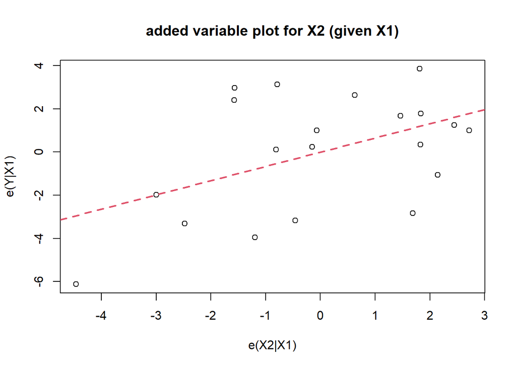

```r
plot(e2.1, eY.1, xlab="e(X2|X1)", ylab="e(Y|X1)", main="added variable plot for X2 (given X1)")
abline(fit2$coefficients, lty=2, lwd=2, col=2)
```

**exercise**: get the added varianle plot of X3 given X1 and X2.

- **Which variable to add next?**  
  Suppose X1 is currently in the model and we want to decide which of X2 and X3 should be added into the model next. We already have the added variable plot for X2 given X1. Let’s get the added variable plot for X3 given X1. Then conduct a side-by-side comparison of these two plots.

```r
eY.1=lm(Y~X1)$residuals
e3.1=lm(X3~X1)$residuals
fit3=lm(eY.1~e3.1)
summary(fit3)
```

```
##
## Call:
## lm(formula = eY.1 ~ e3.1)
##
## Residuals:
##     Min      1Q  Median      3Q     Max
## -3.8794 -1.9627  0.3811  1.2688  3.8942
##
## Coefficients:
##               Estimate Std. Error t value Pr(>|t|)
## (Intercept)  4.965e-16  5.425e-01   0.000   1.0000
## e3.1        -4.314e-01  1.716e-01  -2.514   0.0217 *
## ---
## Signif. codes:  0 '***' 0.001 '**' 0.01 '*' 0.05 '.' 0.1 ' ' 1
##
## Residual standard error: 2.426 on 18 degrees of freedom
## Multiple R-squared:  0.2598, Adjusted R-squared:  0.2187
## F-statistic: 6.318 on 1 and 18 DF,  p-value: 0.02168
```

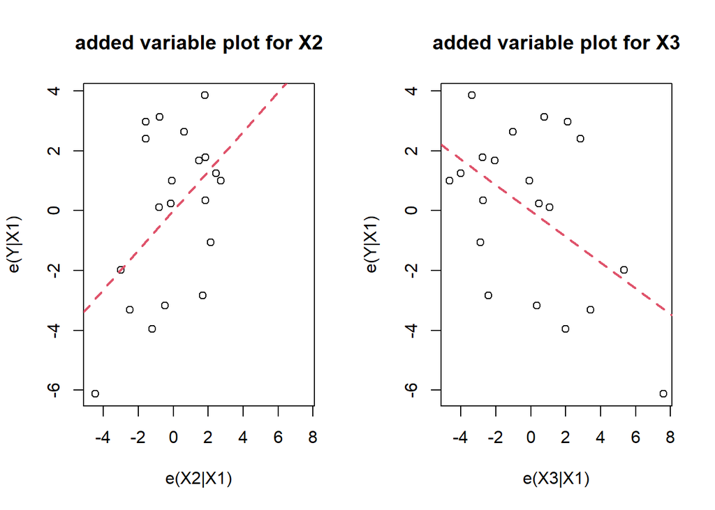

```r
x.lim=range(e2.1, e3.1)
y.lim=range(eY.1)
par(mfrow=c(1,2))
plot(e2.1, eY.1, xlab="e(X2|X1)", ylab="e(Y|X1)", xlim=x.lim, ylim=y.lim, main="added variable plot for X2")
abline(fit2$coefficients, lty=2, lwd=2, col=2)

plot(e3.1, eY.1, xlab="e(X3|X1)", ylab="e(Y|X1)", xlim=x.lim, ylim=y.lim, main="added variable plot for X3")
abline(fit3$coefficients, lty=2, lwd=2, col=2)
```

**exercise**: Suppose the current model contains X2. Use the added variable plots to decide on which of X1 and X3 should be added into the model next.

## Missing values in R

In R, missing values are represented by the symbol *NA* (not available) . Impossible values (e.g., dividing by zero) are represented by the symbol *NaN* (not a number). However, missing values in the original files could be represented by " “,”?“,”missing“, etc. instead of”NA“. We need to be very careful when we transform these kinds of missing values into”NA" in R. Now we consider another data set *cars*. We first read the data into R:

```r
cars = read.csv('Cars.csv', header=TRUE)
```

We just focus on the variable *horsepower* for illustration purpose. We can check its class in R:

```r
class(cars$horsepower)
```

```
## [1] "character"
```

It seems weird because we expect the class of “horsepower” to be numeric. The reason is that we have the unexpected value “?” in the data set, representing the missing value, and R will not treat this as numeric.

To transform the class of “horsepower”:

```r
as.numeric(cars$horsepower)
```

```
##   [1] 130 165 150 150 140 198 220 215 225 190 170 160 150 225  95  95  97  85
##  [19]  88  46  87  90  95 113  90 215 200 210 193  88  90  95  NA 100 105 100
##  [37]  88 100 165 175 153 150 180 170 175 110  72 100  88  86  90  70  76  65
##  [55]  69  60  70  95  80  54  90  86 165 175 150 153 150 208 155 160 190  97
##  [73] 150 130 140 150 112  76  87  69  86  92  97  80  88 175 150 145 137 150
##  [91] 198 150 158 150 215 225 175 105 100 100  88  95  46 150 167 170 180 100
## [109]  88  72  94  90  85 107  90 145 230  49  75  91 112 150 110 122 180  95
## [127]  NA 100 100  67  80  65  75 100 110 105 140 150 150 140 150  83  67  78
## [145]  52  61  75  75  75  97  93  67  95 105  72  72 170 145 150 148 110 105
## [163] 110  95 110 110 129  75  83 100  78  96  71  97  97  70  90  95  88  98
## [181] 115  53  86  81  92  79  83 140 150 120 152 100 105  81  90  52  60  70
## [199]  53 100  78 110  95  71  70  75  72 102 150  88 108 120 180 145 130 150
## [217]  68  80  58  96  70 145 110 145 130 110 105 100  98 180 170 190 149  78
## [235]  88  75  89  63  83  67  78  97 110 110  48  66  52  70  60 110 140 139
## [253] 105  95  85  88 100  90 105  85 110 120 145 165 139 140  68  95  97  75
## [271]  95 105  85  97 103 125 115 133  71  68 115  85  88  90 110 130 129 138
## [289] 135 155 142 125 150  71  65  80  80  77 125  71  90  70  70  65  69  90
## [307] 115 115  90  76  60  70  65  90  88  90  90  78  90  75  92  75  65 105
## [325]  65  48  48  67  67  67  NA  67  62 132 100  88  NA  72  84  84  92 110
## [343]  84  58  64  60  67  65  62  68  63  65  65  74  NA  75  75 100  74  80
## [361]  76 116 120 110 105  88  85  88  88  88  85  84  90  92  74  68  68  63
## [379]  70  88  75  70  67  67  67 110  85  92 112  96  84  90  86  52  84  79
## [397]  82
```

Now we can check the class:

```r
cars$horsepower <- as.numeric(cars$horsepower)
class(cars$horsepower)
```

```
## [1] "numeric"
```

How many missing values are there?

```r
sum(is.na(cars$horsepower))
```

```
## [1] 5
```

```r
#To extract the positions of NA
which(is.na(cars$horsepower))
```

```
## [1]  33 127 331 337 355
```

Now, we can remove the NAs using `is.na()` function:

```r
cars$horsepower[!is.na(cars$horsepower)]###Gives components not NA
```

```
##   [1] 130 165 150 150 140 198 220 215 225 190 170 160 150 225  95  95  97  85
##  [19]  88  46  87  90  95 113  90 215 200 210 193  88  90  95 100 105 100  88
##  [37] 100 165 175 153 150 180 170 175 110  72 100  88  86  90  70  76  65  69
##  [55]  60  70  95  80  54  90  86 165 175 150 153 150 208 155 160 190  97 150
##  [73] 130 140 150 112  76  87  69  86  92  97  80  88 175 150 145 137 150 198
##  [91] 150 158 150 215 225 175 105 100 100  88  95  46 150 167 170 180 100  88
## [109]  72  94  90  85 107  90 145 230  49  75  91 112 150 110 122 180  95 100
## [127] 100  67  80  65  75 100 110 105 140 150 150 140 150  83  67  78  52  61
## [145]  75  75  75  97  93  67  95 105  72  72 170 145 150 148 110 105 110  95
## [163] 110 110 129  75  83 100  78  96  71  97  97  70  90  95  88  98 115  53
## [181]  86  81  92  79  83 140 150 120 152 100 105  81  90  52  60  70  53 100
## [199]  78 110  95  71  70  75  72 102 150  88 108 120 180 145 130 150  68  80
## [217]  58  96  70 145 110 145 130 110 105 100  98 180 170 190 149  78  88  75
## [235]  89  63  83  67  78  97 110 110  48  66  52  70  60 110 140 139 105  95
## [253]  85  88 100  90 105  85 110 120 145 165 139 140  68  95  97  75  95 105
## [271]  85  97 103 125 115 133  71  68 115  85  88  90 110 130 129 138 135 155
## [289] 142 125 150  71  65  80  80  77 125  71  90  70  70  65  69  90 115 115
## [307]  90  76  60  70  65  90  88  90  90  78  90  75  92  75  65 105  65  48
## [325]  48  67  67  67  67  62 132 100  88  72  84  84  92 110  84  58  64  60
## [343]  67  65  62  68  63  65  65  74  75  75 100  74  80  76 116 120 110 105
## [361]  88  85  88  88  88  85  84  90  92  74  68  68  63  70  88  75  70  67
## [379]  67  67 110  85  92 112  96  84  90  86  52  84  79  82
```

```r
##alternative way to get rid of NA
cars$horsepower[complete.cases(cars$horsepower)]
```

```
##   [1] 130 165 150 150 140 198 220 215 225 190 170 160 150 225  95  95  97  85
##  [19]  88  46  87  90  95 113  90 215 200 210 193  88  90  95 100 105 100  88
##  [37] 100 165 175 153 150 180 170 175 110  72 100  88  86  90  70  76  65  69
##  [55]  60  70  95  80  54  90  86 165 175 150 153 150 208 155 160 190  97 150
##  [73] 130 140 150 112  76  87  69  86  92  97  80  88 175 150 145 137 150 198
##  [91] 150 158 150 215 225 175 105 100 100  88  95  46 150 167 170 180 100  88
## [109]  72  94  90  85 107  90 145 230  49  75  91 112 150 110 122 180  95 100
## [127] 100  67  80  65  75 100 110 105 140 150 150 140 150  83  67  78  52  61
## [145]  75  75  75  97  93  67  95 105  72  72 170 145 150 148 110 105 110  95
## [163] 110 110 129  75  83 100  78  96  71  97  97  70  90  95  88  98 115  53
## [181]  86  81  92  79  83 140 150 120 152 100 105  81  90  52  60  70  53 100
## [199]  78 110  95  71  70  75  72 102 150  88 108 120 180 145 130 150  68  80
## [217]  58  96  70 145 110 145 130 110 105 100  98 180 170 190 149  78  88  75
## [235]  89  63  83  67  78  97 110 110  48  66  52  70  60 110 140 139 105  95
## [253]  85  88 100  90 105  85 110 120 145 165 139 140  68  95  97  75  95 105
## [271]  85  97 103 125 115 133  71  68 115  85  88  90 110 130 129 138 135 155
## [289] 142 125 150  71  65  80  80  77 125  71  90  70  70  65  69  90 115 115
## [307]  90  76  60  70  65  90  88  90  90  78  90  75  92  75  65 105  65  48
## [325]  48  67  67  67  67  62 132 100  88  72  84  84  92 110  84  58  64  60
## [343]  67  65  62  68  63  65  65  74  75  75 100  74  80  76 116 120 110 105
## [361]  88  85  88  88  88  85  84  90  92  74  68  68  63  70  88  75  70  67
## [379]  67  67 110  85  92 112  96  84  90  86  52  84  79  82
```

The function `complete.cases` returns a logical vector indicating which cases (rows) are complete (have no missing values).

```r
which(!complete.cases(cars))
```

```
## [1]  33 127 331 337 355
```

## Strings in R

We will often need to manipulate strings in R, e.g plotting. One of the most useful functions is *paste()* which combines strings (concatentates) into one and/or multiple strings. Using the following definition, *paste(…, sep=" ", collapse=NULL)*, we have some quick examples.

```r
paste("x",1:3,sep='_')##Separate strings
```

```
## [1] "x_1" "x_2" "x_3"
```

```r
paste("x",1:3,sep='_',collapse = ", ")##Collapses into a single string
```

```
## [1] "x_1, x_2, x_3"
```

```r
paste0("x",1:3,collapse = ',') # paste0 is paste with sep=""
```

```
## [1] "x1,x2,x3"
```

```r
nth <- paste0(1:12, c("st", "nd", "rd", rep("th", 9)))
nth
```

```
##  [1] "1st"  "2nd"  "3rd"  "4th"  "5th"  "6th"  "7th"  "8th"  "9th"  "10th"
## [11] "11th" "12th"
```

Let’s look into a few other examples:

```r
wrd = c("a","beautiful","day") # a vector of three elements
wrd
```

```
## [1] "a"         "beautiful" "day"
```

```r
x = c(1,9,3)
u = c("_","!","?")
paste0(wrd,u,x)
```

```
## [1] "a_1"         "beautiful!9" "day?3"
```

```r
paste0(wrd,u,x, collapse = " ")
```

```
## [1] "a_1 beautiful!9 day?3"
```

### strsplit

*strsplit()* function splits the elements of a character vector into substrings.

```r
sen.p = paste(wrd[1],wrd[2],wrd[3])##" " is the default separator
sen.p
```

```
## [1] "a beautiful day"
```

```r
sen.wrd=strsplit(sen.p,split=" ")[[1]]
sen.wrd
```

```
## [1] "a"         "beautiful" "day"
```

```r
typeof(sen.wrd)###Creates a list
```

```
## [1] "character"
```

```r
typeof(sen.p)
```

```
## [1] "character"
```

```r
cat("My name is", "Sam", sep = " ")###concatenates and prints
```

```
## My name is Sam
```

Now, let’s look into some functions applied to strings.

```r
fun1 <- function(m=1){
  return(cat(rep("Are you excited ?", m), "\n"))  # prints the phrase m times
}
fun1(5)
```

```
## Are you excited ? Are you excited ? Are you excited ? Are you excited ? Are you excited ?
```

Another important function is *sprintf()*. It returns a character vector containing a formatted combination of text and variable values.

```r
paste("what does the", 1, "say")
```

```
## [1] "what does the 1 say"
```

```r
sprintf("What does the %s say?!", "fox")
```

```
## [1] "What does the fox say?!"
```

There are lots of formats you can specify. Here are some examples.

```r
# Notation | Description
# ----------------------------------------------
# %s       | a string
# %d       | an integer
# %i       | an integer
# %f       | decimal notation with six decimals


sprintf("%+f", pi)
```

```
## [1] "+3.141593"
```

```r
sprintf("%.3f", pi)
```

```
## [1] "3.142"
```

```r
sprintf("%05.1f", pi)
```

```
## [1] "003.1"
```

```r
sprintf("%-10f", pi) # left justified
```

```
## [1] "3.141593  "
```

```r
sprintf("%e", pi)
```

```
## [1] "3.141593e+00"
```

It can work for vectors as well:

```r
sprintf("What does the %s say?!", c("cat", "dog", "fox"))
```

```
## [1] "What does the cat say?!" "What does the dog say?!"
## [3] "What does the fox say?!"
```

**Exercise:** Consider the names of the following people. Create a function that prints, for example, “Lily is saying hello!” and use “sapply” to apply this function to the vector of names.

```r
names = c("Sun", "Moon", "Star")

say_hello =function(i){
  ##Fill in the details
}

##sapply(#fill in the details)
```

## Standardization of variables

We can use the **scale()** function to create standardized variables. Standardized variables in general have mean 0 and standard deviation 1.

```r
x = runif(100)
sc.x = scale(x)
mean(sc.x)
```

```
## [1] -7.02563e-17
```

```r
sd(sc.x)
```

```
## [1] 1
```